# Final Project: Predicting Hall of Fame NBA Players after First 3 Seasons

December 20, 2018

## Background

```
##  [1] "From"               "To"                 "Tm"
##  [4] "Lg"                 "WS"                 "G"
##  [7] "GS"                 "MP"                 "FG"
## [10] "FGA"                "X2P"                "X2PA"
## [13] "X3P"                "X3PA"               "FT"
## [16] "FTA"                "ORB"                "DRB"
## [19] "TRB"                "AST"                "STL"
## [22] "BLK"                "TOV"                "PF"
## [25] "PTS"                "FG_PERC"            "X2P_PERC"
## [28] "X3P_PERC"           "eFG_PERC"           "FT_PERC"
## [31] "TS_PERC"            "All_Star"           "MVP"
## [34] "DPOY"               "ROY"                "All_NBA"
## [37] "All_Rookie"         "All_Defensive_Team" "Champion"
## [40] "Hall_of_Fame"
```

## Visualization: Distribution of Target Variable

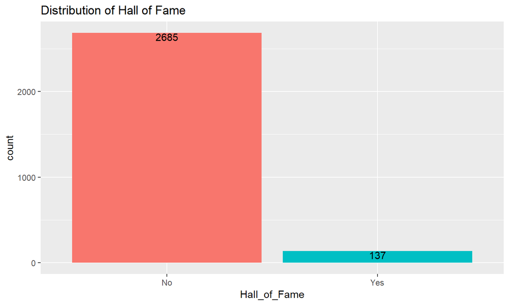

## Free Throws Attempted by Hall of Fame

[interactive chart not shown]

## Win Shares by Hall of Fame

[interactive chart not shown]

## Three Pointers over Time

[interactive chart not shown]

## Visualization: Variable Importance

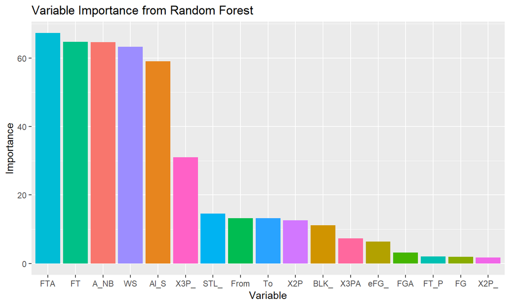

## Correlation

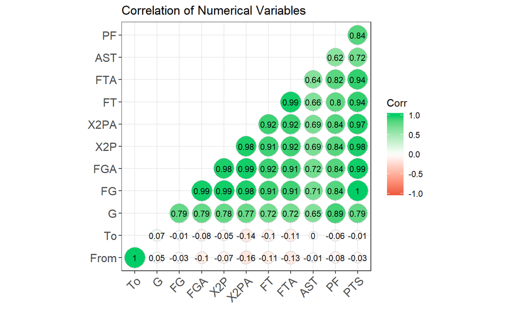

## Missing Values

| Variable | Missing | Variable | Missing | Variable | Missing |
| --- | --- | --- | --- | --- | --- |
| Tm | 1304 | X3PA | 1108 | TOV | 1020 |
| Lg | 72 | ORB | 860 | FG_PERC | 5 |
| WS | 2 | DRB | 860 | X2P_PERC | 6 |
| GS | 1195 | TRB | 247 | X3P_PERC | 1304 |
| MP | 299 | STL | 860 | eFG_PERC | 5 |
| X3P | 1108 | BLK | 860 | FT_PERC | 33 |

## Imputation Notes & Methods

- 3 point line did not exist until 1979
- Offensive and defensive rebounds, steals, and blocks didn't start being tracked until 1973
- Team, League, and Games Started variables are deleted
- **Methods**
- *Remove*
  - When taking only clean observations, the data set is reduced to 1511 observations
- *KNN*
  - Keeps all 2822 observations
- *Custum Method*
  - Back into numbers so syntax is met
  - Ex. Offensive plus defensive rebounds must equal total rebounds

## Data Partition & Balancing Data

- 70% training data and 30% testing data
- Testing data is held consisten to ensure unbias evaluation
- Only 5% of players go to the hall of fame so the data must be balanced before modeling
- Oversampling is used in order to maintain a reasonable sample size

```r
oversample <- function(df)
{
  set.seed(100)
  split <- createDataPartition(df$Hall_of_Fame, p = .7, list=FALSE, times=1)
  training <- df[split,]
  testing <- df[-split,]

  trainY <- training[training$Hall_of_Fame == "Yes",]
  trainN <- training[training$Hall_of_Fame == "No",]

  nY <- nrow(trainY)
  nN <- nrow(trainN)

  trainYY <- sample_n(trainY, nN, replace = TRUE)
  train_over <- rbind(trainYY, trainN)

  return(list(train_over, testing))
}
```

## Models

- Random Forest
- GLMnet
- Support Vector Machine
- Neural Network

```r
rf <- function(df, test)
{
  set.seed(123)
  random_forest <- ranger(Hall_of_Fame ~ ., data = df)
  rf_predict <- predict(random_forest, data = test)$predictions
  cm <- confusionMatrix(rf_predict, reference = test[,"Hall_of_Fame"], positive = "Yes")
  return(cm)
}

rf.remove <- rf(train.remove, test.remove)
rf.knn <- rf(train.knn, test.knn)
rf.custom <- rf(train.custom, test.custom)
```

## Compare

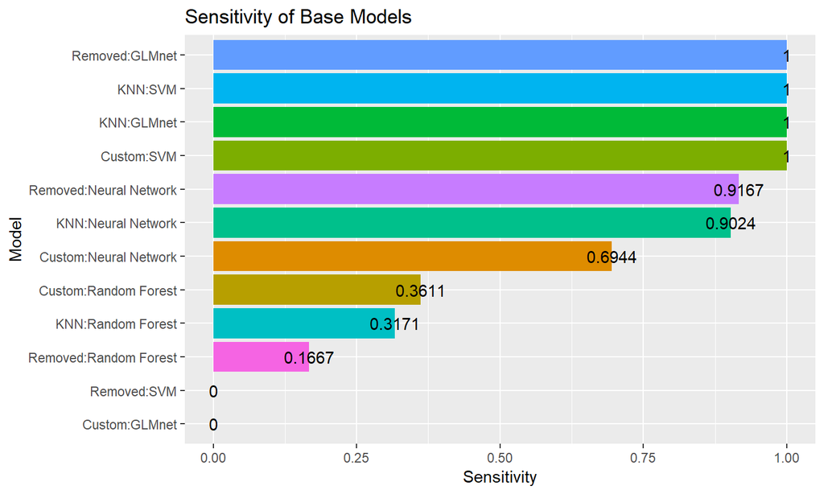

## Compare (cont.)

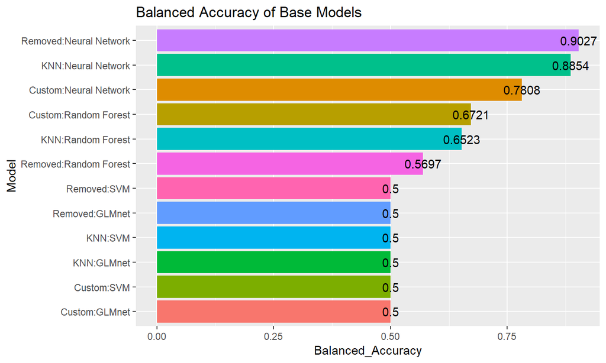

## Encoding/Recoding Variables

- Repetitive/correlated variables are deleted (FG, PERC, MVP, DPOY, etc.)
- **Methods**
- *Binned*
  - Grouped all continuous variables into 5 categories (same number of dimensions)
- *PCA*
  - Reduces number of variables to 13
- *Custom Method*
  - Also reduces the number of variables to 13
  - Standardize values by making statistics per game

## Models after Variable Manipulation

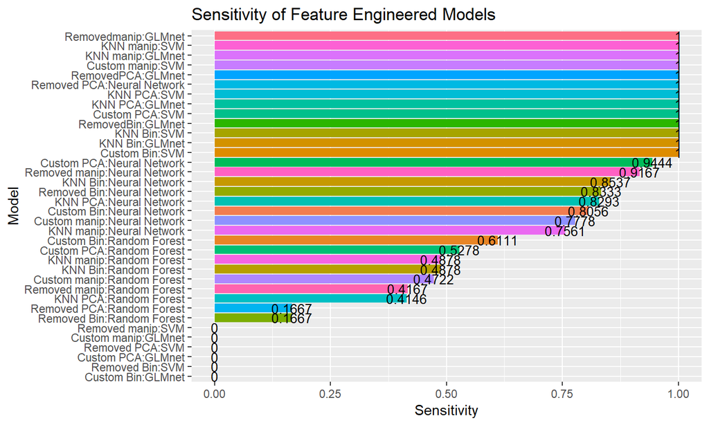

## Models after Variable Manipulation (cont.)

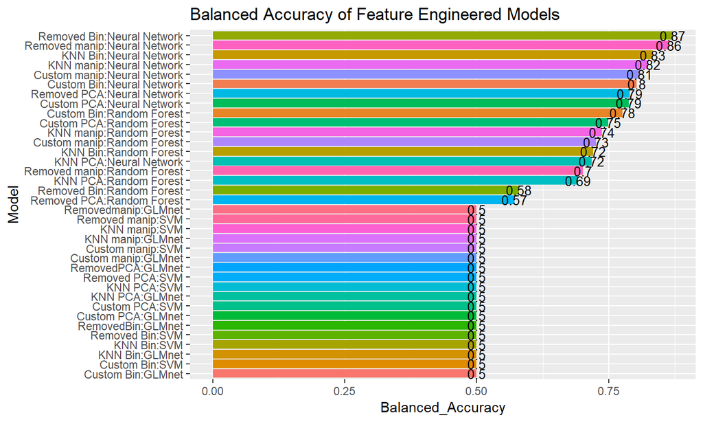

## Thank you, any questions?